# AEi Term Paper - Cointegration

2023-12-14

Import all required packages

```r
library(readxl)
library(lmtest)
library(janitor)
library(tidyverse)
library(tseries)
library(forecast)
library(gridExtra)
library(jtools)
library(urca)
library(vars)
```

Import data

```r
data1 <- read_excel("C:/Users/sarka/OneDrive/Base Sem 1/term papers/AEi term paper/datasets/final dataset.xlsx", sheet=4)
View(data1)
head(data1)
```

```
## # A tibble: 6 × 3
##    Year `Employment rate (in %)` `Trade (as % of GDP)`
##   <dbl>                    <dbl>                 <dbl>
## 1  1991                     14.9                  17.0
## 2  1992                     15.1                  18.4
## 3  1993                     15.2                  19.7
## 4  1994                     15.4                  20.1
## 5  1995                     15.6                  22.9
## 6  1996                     15.7                  21.9
```

- renaming the variable names

```r
data1 <- rename(data1, "emp_rate"="Employment rate (in %)")
data1 <- rename(data1, "trade_amount"="Trade (as % of GDP)")

names(data1)
```

```
## [1] "Year"         "emp_rate"     "trade_amount"
```

summary statistics

```r
summary(data1)
```

```
##       Year         emp_rate      trade_amount
##  Min.   :1991   Min.   :14.92   Min.   :16.99
##  1st Qu.:1998   1st Qu.:16.06   1st Qu.:24.26
##  Median :2006   Median :19.37   Median :39.91
##  Mean   :2006   Mean   :19.92   Mean   :36.38
##  3rd Qu.:2014   3rd Qu.:24.39   3rd Qu.:45.71
##  Max.   :2021   Max.   :25.37   Max.   :55.79
```

```r
nrow(data1)
```

```
## [1] 31
```

```r
str(data1)
```

```
## tibble [31 × 3] (S3: tbl_df/tbl/data.frame)
##  $ Year        : num [1:31] 1991 1992 1993 1994 1995 ...
##  $ emp_rate    : num [1:31] 14.9 15.1 15.2 15.4 15.6 ...
##  $ trade_amount: num [1:31] 17 18.4 19.7 20.1 22.9 ...
```

```r
sd(data1$emp_rate)
```

```
## [1] 3.924328
```

```r
sd(data1$trade_amount)
```

```
## [1] 12.35933
```

-checking missing values

```r
colSums(is.na(data1))
```

```
##         Year     emp_rate trade_amount
##            0            0            0
```

GRAPH 1. Relationship between India’s Employment rate and Trade

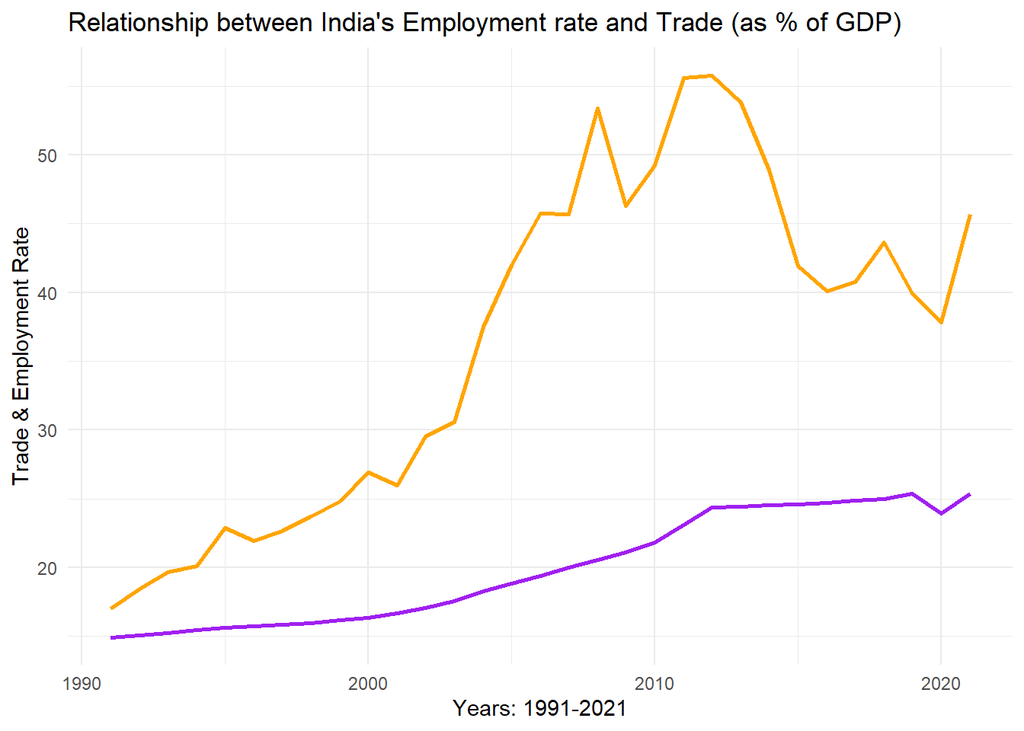

```r
ggplot(data1) + geom_line(aes(x=Year, y=emp_rate), col="purple", size=1) + geom_line(aes(x=Year, y=trade_amount), col="orange", size=1) + ggtitle("Relationship between India's Employment rate and Trade (as % of GDP)") + xlab("Years: 1991-2021") + ylab("Trade & Employment Rate") + theme_minimal()
```

Separate graphs of Employment rate and Trade

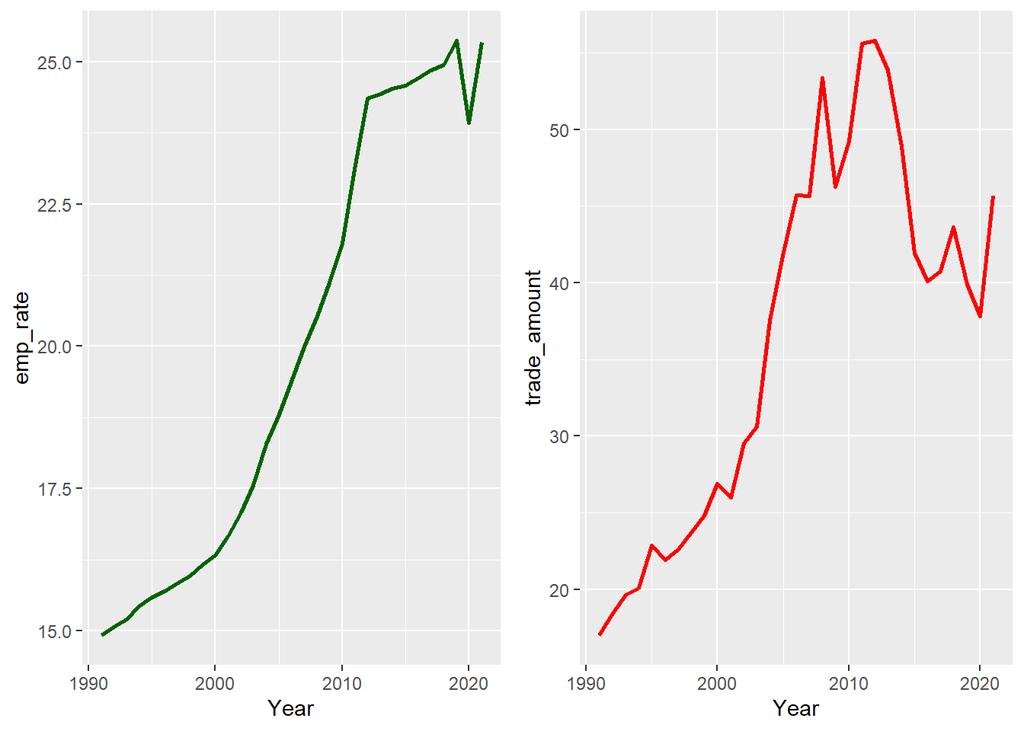

```r
a <- ggplot(data1) + geom_line(aes(x=Year, y=emp_rate), col="darkgreen", size=1)
b <- ggplot(data1) + geom_line(aes(x=Year, y=trade_amount), col="red", size=1)
grid.arrange(a, b, ncol=2, nrow=1)
```

Convert into time series

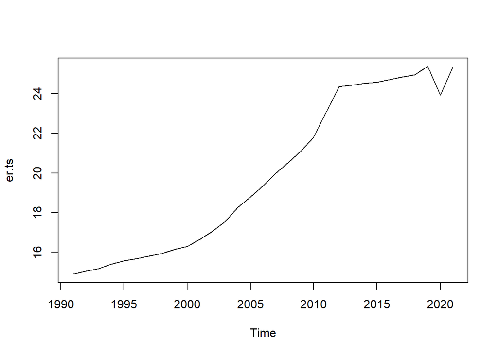

```r
er.ts <- ts(data1$emp_rate, start=c(1991,1), frequency=1)
plot(er.ts)
```

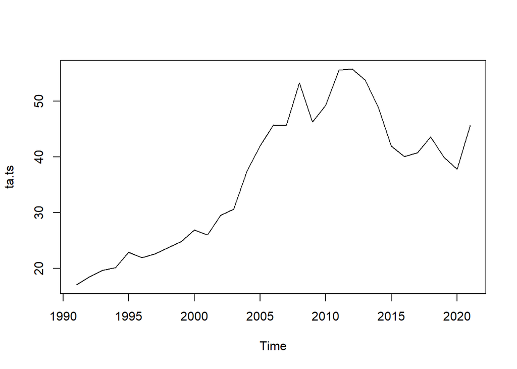

```r
ta.ts <- ts(data1$trade_amount, start=c(1991,1), frequency=1)
plot(ta.ts)
```

checking the stationarity of the variables (i) for total employment rate

```r
a1 <- ur.df(er.ts, type="drift", selectlags="AIC")
summary(a1)
```

```
##
## ###############################################
## # Augmented Dickey-Fuller Test Unit Root Test #
## ###############################################
##
## Test regression drift
##
##
## Call:
## lm(formula = z.diff ~ z.lag.1 + 1 + z.diff.lag)
##
## Residuals:
##     Min      1Q  Median      3Q     Max
## -1.7578 -0.2363 -0.1560  0.2093  1.0524
##
## Coefficients:
##              Estimate Std. Error t value Pr(>|t|)
## (Intercept)  0.475733   0.532632   0.893    0.380
## z.lag.1     -0.005876   0.026098  -0.225    0.824
## z.diff.lag  -0.014177   0.213132  -0.067    0.947
##
## Residual standard error: 0.5269 on 26 degrees of freedom
## Multiple R-squared:  0.002118,   Adjusted R-squared:  -0.07464
## F-statistic: 0.02759 on 2 and 26 DF,  p-value: 0.9728
##
##
## Value of test-statistic is: -0.2251 4.6352
##
## Critical values for test statistics:
##       1pct  5pct 10pct
## tau2 -3.58 -2.93 -2.60
## phi1  7.06  4.86  3.94
```

```r
a2 <- ur.df(er.ts, type="trend", selectlags="AIC")
summary(a2)
```

```
##
## ###############################################
## # Augmented Dickey-Fuller Test Unit Root Test #
## ###############################################
##
## Test regression trend
##
##
## Call:
## lm(formula = z.diff ~ z.lag.1 + 1 + tt + z.diff.lag)
##
## Residuals:
##      Min       1Q   Median       3Q      Max
## -1.87187 -0.13772 -0.02038  0.10803  0.95495
##
## Coefficients:
##             Estimate Std. Error t value Pr(>|t|)
## (Intercept)  2.76922    1.46020   1.896   0.0695 .
## z.lag.1     -0.19235    0.11392  -1.688   0.1038
## tt           0.08599    0.05123   1.679   0.1057
## z.diff.lag   0.12243    0.22154   0.553   0.5854
## ---
## Signif. codes:  0 '***' 0.001 '**' 0.01 '*' 0.05 '.' 0.1 ' ' 1
##
## Residual standard error: 0.5094 on 25 degrees of freedom
## Multiple R-squared:  0.1032, Adjusted R-squared:  -0.004433
## F-statistic: 0.9588 on 3 and 25 DF,  p-value: 0.4275
##
##
## Value of test-statistic is: -1.6884 4.2452 1.4358
##
## Critical values for test statistics:
##       1pct  5pct 10pct
## tau3 -4.15 -3.50 -3.18
## phi2  7.02  5.13  4.31
## phi3  9.31  6.73  5.61
```

according to ADF test, as p-value is greater than 0.05, we do not reject Ho, i.e., Data is not stationary.

```r
a3 <- ur.df(diff(er.ts), type="drift", selectlags="AIC")
summary(a3)
```

```
##
## ###############################################
## # Augmented Dickey-Fuller Test Unit Root Test #
## ###############################################
##
## Test regression drift
##
##
## Call:
## lm(formula = z.diff ~ z.lag.1 + 1 + z.diff.lag)
##
## Residuals:
##      Min       1Q   Median       3Q      Max
## -1.61892 -0.12690  0.00171  0.17996  0.88893
##
## Coefficients:
##             Estimate Std. Error t value Pr(>|t|)
## (Intercept)   0.2040     0.1464   1.393   0.1758
## z.lag.1      -0.6058     0.3058  -1.981   0.0587 .
## z.diff.lag   -0.5917     0.3249  -1.821   0.0805 .
## ---
## Signif. codes:  0 '***' 0.001 '**' 0.01 '*' 0.05 '.' 0.1 ' ' 1
##
## Residual standard error: 0.5035 on 25 degrees of freedom
## Multiple R-squared:  0.531,  Adjusted R-squared:  0.4935
## F-statistic: 14.15 on 2 and 25 DF,  p-value: 7.751e-05
##
##
## Value of test-statistic is: -1.9812 1.9748
##
## Critical values for test statistics:
##       1pct  5pct 10pct
## tau2 -3.58 -2.93 -2.60
## phi1  7.06  4.86  3.94
```

```r
a4 <- ur.df(diff(er.ts), type="trend", selectlags="AIC")
summary(a4)
```

```
##
## ###############################################
## # Augmented Dickey-Fuller Test Unit Root Test #
## ###############################################
##
## Test regression trend
##
##
## Call:
## lm(formula = z.diff ~ z.lag.1 + 1 + tt + z.diff.lag)
##
## Residuals:
##      Min       1Q   Median       3Q      Max
## -1.51315 -0.13090  0.00538  0.18013  0.93121
##
## Coefficients:
##              Estimate Std. Error t value Pr(>|t|)
## (Intercept)  0.300823   0.229058   1.313   0.2015
## z.lag.1     -0.579831   0.313630  -1.849   0.0768 .
## tt          -0.006987   0.012583  -0.555   0.5838
## z.diff.lag  -0.648190   0.344789  -1.880   0.0723 .
## ---
## Signif. codes:  0 '***' 0.001 '**' 0.01 '*' 0.05 '.' 0.1 ' ' 1
##
## Residual standard error: 0.5107 on 24 degrees of freedom
## Multiple R-squared:  0.537,  Adjusted R-squared:  0.4791
## F-statistic: 9.278 on 3 and 24 DF,  p-value: 0.000296
##
##
## Value of test-statistic is: -1.8488 1.3829 2.0624
##
## Critical values for test statistics:
##       1pct  5pct 10pct
## tau3 -4.15 -3.50 -3.18
## phi2  7.02  5.13  4.31
## phi3  9.31  6.73  5.61
```

2. for trade

```r
b1 <- ur.df(ta.ts, type="drift", selectlags="AIC")
summary(b1)
```

```
##
## ###############################################
## # Augmented Dickey-Fuller Test Unit Root Test #
## ###############################################
##
## Test regression drift
##
##
## Call:
## lm(formula = z.diff ~ z.lag.1 + 1 + z.diff.lag)
##
## Residuals:
##     Min      1Q  Median      3Q     Max
## -7.0176 -1.9848 -0.6227  2.2779  7.5426
##
## Coefficients:
##             Estimate Std. Error t value Pr(>|t|)
## (Intercept)  4.00492    2.32236   1.725   0.0965 .
## z.lag.1     -0.08456    0.06002  -1.409   0.1707
## z.diff.lag   0.05602    0.20100   0.279   0.7827
## ---
## Signif. codes:  0 '***' 0.001 '**' 0.01 '*' 0.05 '.' 0.1 ' ' 1
##
## Residual standard error: 3.851 on 26 degrees of freedom
## Multiple R-squared:  0.07358,    Adjusted R-squared:  0.002318
## F-statistic: 1.033 on 2 and 26 DF,  p-value: 0.3703
##
##
## Value of test-statistic is: -1.409 1.7509
##
## Critical values for test statistics:
##       1pct  5pct 10pct
## tau2 -3.58 -2.93 -2.60
## phi1  7.06  4.86  3.94
```

```r
b2 <- ur.df(ta.ts, type="trend", selectlags="AIC")
summary(b2)
```

```
##
## ###############################################
## # Augmented Dickey-Fuller Test Unit Root Test #
## ###############################################
##
## Test regression trend
##
##
## Call:
## lm(formula = z.diff ~ z.lag.1 + 1 + tt + z.diff.lag)
##
## Residuals:
##     Min      1Q  Median      3Q     Max
## -6.8148 -1.9744 -0.7995  1.7838  7.9502
##
## Coefficients:
##             Estimate Std. Error t value Pr(>|t|)
## (Intercept)  4.33641    2.42044   1.792   0.0853 .
## z.lag.1     -0.13487    0.10567  -1.276   0.2136
## tt           0.09185    0.15783   0.582   0.5658
## z.diff.lag   0.12070    0.23196   0.520   0.6074
## ---
## Signif. codes:  0 '***' 0.001 '**' 0.01 '*' 0.05 '.' 0.1 ' ' 1
##
## Residual standard error: 3.901 on 25 degrees of freedom
## Multiple R-squared:  0.08596,    Adjusted R-squared:  -0.02372
## F-statistic: 0.7837 on 3 and 25 DF,  p-value: 0.5142
##
##
## Value of test-statistic is: -1.2763 1.2505 1.1367
##
## Critical values for test statistics:
##       1pct  5pct 10pct
## tau3 -4.15 -3.50 -3.18
## phi2  7.02  5.13  4.31
## phi3  9.31  6.73  5.61
```

according to ADF test, as p-value is greater than 0.05, we fail to reject Ho, i.e., Data is not stationary.

```r
b3 <- ur.df(diff(ta.ts), type="drift", selectlags="AIC")
summary(b3)
```

```
##
## ###############################################
## # Augmented Dickey-Fuller Test Unit Root Test #
## ###############################################
##
## Test regression drift
##
##
## Call:
## lm(formula = z.diff ~ z.lag.1 + 1 + z.diff.lag)
##
## Residuals:
##     Min      1Q  Median      3Q     Max
## -8.3579 -2.0112  0.1099  2.2492  7.2461
##
## Coefficients:
##             Estimate Std. Error t value Pr(>|t|)
## (Intercept)  0.86307    0.79964   1.079  0.29075
## z.lag.1     -0.91119    0.28659  -3.179  0.00391 **
## z.diff.lag  -0.03662    0.21633  -0.169  0.86695
## ---
## Signif. codes:  0 '***' 0.001 '**' 0.01 '*' 0.05 '.' 0.1 ' ' 1
##
## Residual standard error: 4.072 on 25 degrees of freedom
## Multiple R-squared:  0.4409, Adjusted R-squared:  0.3962
## F-statistic: 9.859 on 2 and 25 DF,  p-value: 0.000697
##
##
## Value of test-statistic is: -3.1794 5.08
##
## Critical values for test statistics:
##       1pct  5pct 10pct
## tau2 -3.58 -2.93 -2.60
## phi1  7.06  4.86  3.94
```

```r
b4 <- ur.df(diff(ta.ts), type="trend", selectlags="AIC")
summary(b4)
```

```
##
## ###############################################
## # Augmented Dickey-Fuller Test Unit Root Test #
## ###############################################
##
## Test regression trend
##
##
## Call:
## lm(formula = z.diff ~ z.lag.1 + 1 + tt + z.diff.lag)
##
## Residuals:
##     Min      1Q  Median      3Q     Max
## -7.9281 -2.1706 -0.4471  2.4147  7.9911
##
## Coefficients:
##              Estimate Std. Error t value Pr(>|t|)
## (Intercept)  2.172038   1.886368   1.151  0.26089
## z.lag.1     -1.004033   0.313268  -3.205  0.00379 **
## tt          -0.079953   0.104165  -0.768  0.45024
## z.diff.lag   0.006588   0.225280   0.029  0.97691
## ---
## Signif. codes:  0 '***' 0.001 '**' 0.01 '*' 0.05 '.' 0.1 ' ' 1
##
## Residual standard error: 4.105 on 24 degrees of freedom
## Multiple R-squared:  0.4543, Adjusted R-squared:  0.3861
## F-statistic: 6.661 on 3 and 24 DF,  p-value: 0.001977
##
##
## Value of test-statistic is: -3.205 3.5274 5.2659
##
## Critical values for test statistics:
##       1pct  5pct 10pct
## tau3 -4.15 -3.50 -3.18
## phi2  7.02  5.13  4.31
## phi3  9.31  6.73  5.61
```

according to ADF test, as p value is less than 0.05, we reject the null hypothesis, i.e., Data is stationary. so trade is I(1).

Now, we do linear regression. Employment rate - Y variable Trade - X variable

```r
lr_result <- lm(er.ts ~ ta.ts, data=data1)
summ(lr_result, confint=TRUE)
```

```
## MODEL INFO:
## Observations: 31
## Dependent Variable: er.ts
## Type: OLS linear regression
##
## MODEL FIT:
## F(1,29) = 62.32, p = 0.00
## R² = 0.68
## Adj. R² = 0.67
##
## Standard errors: OLS
## --------------------------------------------------------
##                      Est.   2.5%   97.5%   t val.      p
## ----------------- ------- ------ ------- -------- ------
## (Intercept)         10.38   7.77   12.98     8.14   0.00
## ta.ts                0.26   0.19    0.33     7.89   0.00
## --------------------------------------------------------
```

Equation:: Y = 10.38 + 0.26X i.e., there is a positive relationship between the trade of India and the employment rate in industries of india.

capturing residuals

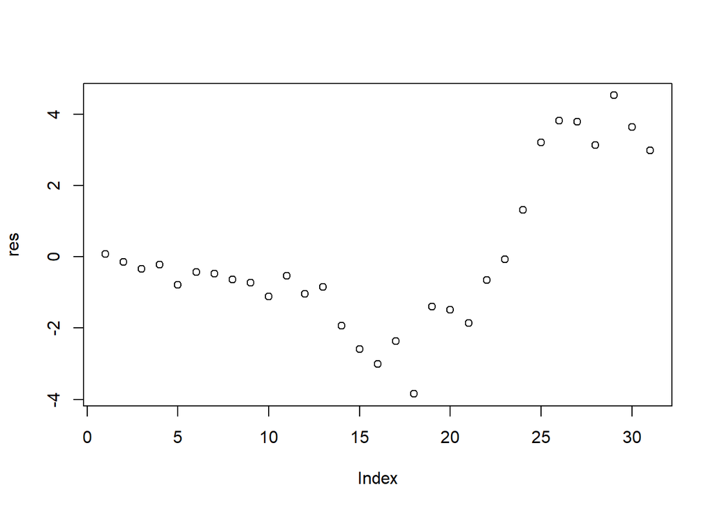

```r
res <- resid(lr_result)
plot(res)
```

```r
ndiffs(res, test="adf", type="trend")
```

```
## [1] 2
```

```r
d1 <- ur.df(res, type="none", selectlags="AIC")
summary(d1)
```

```
##
## ###############################################
## # Augmented Dickey-Fuller Test Unit Root Test #
## ###############################################
##
## Test regression none
##
##
## Call:
## lm(formula = z.diff ~ z.lag.1 - 1 + z.diff.lag)
##
## Residuals:
##      Min       1Q   Median       3Q      Max
## -1.56120 -0.50826 -0.05725  0.51179  2.20713
##
## Coefficients:
##            Estimate Std. Error t value Pr(>|t|)
## z.lag.1    -0.04607    0.08242  -0.559    0.581
## z.diff.lag -0.04137    0.20311  -0.204    0.840
##
## Residual standard error: 0.9162 on 27 degrees of freedom
## Multiple R-squared:  0.01733,    Adjusted R-squared:  -0.05546
## F-statistic: 0.2381 on 2 and 27 DF,  p-value: 0.7897
##
##
## Value of test-statistic is: -0.559
##
## Critical values for test statistics:
##       1pct  5pct 10pct
## tau1 -2.62 -1.95 -1.61
```

as p-value is insignificant and more than 0.05, we will not reject the null hypothesis, i.e., residuals are non-stationary. thus, we can say the variables (Employment rate in industries and Trade) are not cointegrated.

Thus, we can see that Employment rate and Trade are NOT cointegrated, i.e., they do not have a long term relationship.

we will run a VAR model to show the short run relationship of the two variables (Employment rate in industries and Trade of India).

creating a new dataframe of the 2 time series

```r
er.ts <- diff(er.ts)
ta.ts <- diff(ta.ts)

data2 <- cbind(er.ts, ta.ts)
head(data2)
```

```
## Time Series:
## Start = 1992
## End = 1997
## Frequency = 1
##        er.ts      ta.ts
## 1992 0.14726  1.4453725
## 1993 0.13268  1.2184407
## 1994 0.22853  0.4266046
## 1995 0.16072  2.7893043
## 1996 0.11832 -0.9379608
## 1997 0.12825  0.6898990
```

```r
View(data2)
```

selecting lags

```r
varlags <- VARselect(data2, lag.max=20, type="const")
varlags$selection
```

```
## AIC(n)  HQ(n)  SC(n) FPE(n)
##      5      5      5      5
```

running VAR model

```r
var_model <- VAR(data2, p=5, type="trend")
var_model
```

```
##
## VAR Estimation Results:
## =======================
##
## Estimated coefficients for equation er.ts:
## ==========================================
## Call:
## er.ts = er.ts.l1 + ta.ts.l1 + er.ts.l2 + ta.ts.l2 + er.ts.l3 + ta.ts.l3 + er.ts.l4 + ta.ts.l4 + er.ts.l5 + ta.ts.l5 + trend
##
##    er.ts.l1    ta.ts.l1    er.ts.l2    ta.ts.l2    er.ts.l3    ta.ts.l3
## -0.34988064  0.04490209  0.89362786 -0.04393845 -0.14366044 -0.02629211
##    er.ts.l4    ta.ts.l4    er.ts.l5    ta.ts.l5       trend
## -0.34454556  0.08113799 -0.48317609  0.09086147  0.02188934
##
##
## Estimated coefficients for equation ta.ts:
## ==========================================
## Call:
## ta.ts = er.ts.l1 + ta.ts.l1 + er.ts.l2 + ta.ts.l2 + er.ts.l3 + ta.ts.l3 + er.ts.l4 + ta.ts.l4 + er.ts.l5 + ta.ts.l5 + trend
##
##   er.ts.l1   ta.ts.l1   er.ts.l2   ta.ts.l2   er.ts.l3   ta.ts.l3   er.ts.l4
##  2.3517964 -0.3841408  6.2994612 -0.3195149 -9.2898507  0.2411853 -4.6423341
##   ta.ts.l4   er.ts.l5   ta.ts.l5      trend
##  0.7890177 -6.6599117  0.4146956  0.2594184
```

performing IRF

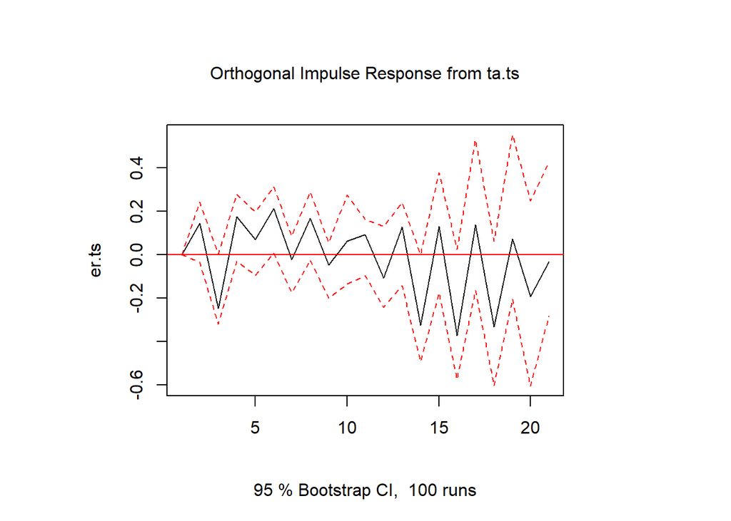

```r
irf1 <- irf(var_model, impulse="ta.ts", response="er.ts", n.ahead=20)
plot(irf1)
```

finding granger causality

```r
varcause1 <- causality(var_model, cause="ta.ts")
varcause1
```

```
## $Granger
##
##  Granger causality H0: ta.ts do not Granger-cause er.ts
##
## data:  VAR object var_model
## F-Test = 3.3512, df1 = 5, df2 = 28, p-value = 0.01697
##
##
## $Instant
##
##  H0: No instantaneous causality between: ta.ts and er.ts
##
## data:  VAR object var_model
## Chi-squared = 6.7201, df = 1, p-value = 0.009533
```

as p-value is less than 0.05, we will REJECT the null hypothesis, i.e., the trade of India will GRANGER CAUSE the employment rate in industries in India.